# EMA-CleanR

## 2.7 Time to Completion (TTC) Flag

Find total time it took to complete survey and identify flags

```r
# Calculate the time difference in mins
EMA.DIGIT2<- EMA.DIGIT2 %>%
  mutate(time_diff =as.integer(difftime(EMA.DIGIT2$end_datetime, EMA.DIGIT2$start_datetime, units = "secs"))) %>% relocate(time_diff, .before = start_day)

## Create a cutoff time for surveys that are taking longer, where SDcuthigh == mean + 2SD
mean <- mean(EMA.DIGIT2$time_diff, na.rm = TRUE)
mean
```

```
## [1] 178.9655
```

```r
sd <- sd(EMA.DIGIT2$time_diff, na.rm = TRUE)
sd
```

```
## [1] 1429.678
```

```r
SDcuthigh <- mean + (2*sd)
SDcuthigh
```

```
## [1] 3038.321
```

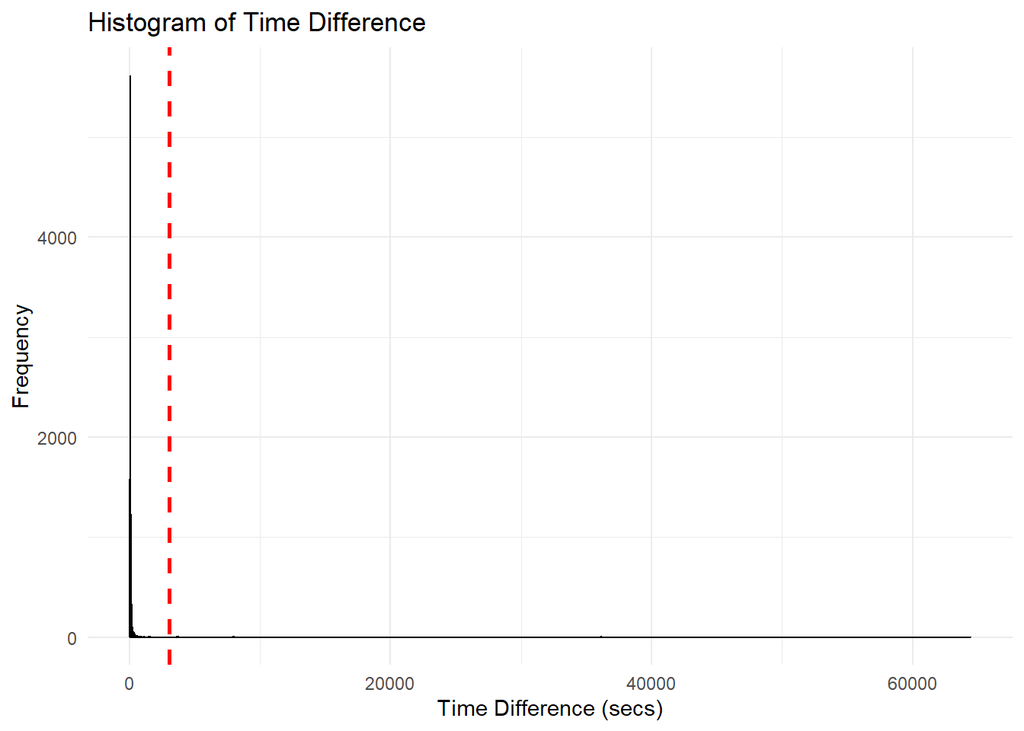

```r
# Create a binary flag variable based on SDcuthigh condition
EMA.DIGIT2$TTCFlag_High <- ifelse(EMA.DIGIT2$time_diff > SDcuthigh, 1, 0)

## Visualize time_diff in a histogram, where red line shows our SDcuthigh threshold
ggplot(EMA.DIGIT2, aes(x = time_diff)) +
  geom_histogram(binwidth = 5, fill = plot_colors["um_blue"], color = "black") +
  geom_vline(xintercept = SDcuthigh, color = "red", linetype = "dashed", size = 1) +  # Add vertical red line
  labs(title = "Histogram of Time Difference",
       x = "Time Difference (secs)",
       y = "Frequency") +
  theme_minimal()
```

```r
## Identify the timediff low. Theoretically, we choose the minimum as someone who completes all possible items in less than 1 second per item. In the EBI study, we had 23 items, so the code below originally used 23 seconds, even though not all 23 items are included in our deidentified data file. To generalize it, the code was modified to use length(ema_vars) which would yield the number of items in the actual data file. One item = 1 second minimum to complete.

EMA.DIGIT2$TTCFlag_Low <- ifelse(EMA.DIGIT2$time_diff < length(ema_vars), 1, 0)
```

# 3 Flags

## 3.1 Low Variance (SD) Flag

Calculate SD for items with Likert Scale and create flags

```r
## If there is zero variance across all ema items, SD_Flag == 1
last_ema_var <- tail(ema_vars, 1)
EMA.DIGIT3 <- EMA.DIGIT2 %>%
  mutate(
    sd_EMA = apply(select(., all_of(ema_vars)), 1, sd, na.rm = TRUE),
    SD_Flag = if_else(sd_EMA == 0, 1, 0)
  ) %>%
  relocate(sd_EMA, SD_Flag, .after = last_ema_var)
```

## 3.2 Flag Review

```r
## Create a df with IDs and the counts and percentages of data that are flagged
summary_df <- EMA.DIGIT3 %>%
  group_by(participantidentifier) %>%
  summarise(
    TTCFlag_High = sum(TTCFlag_High, na.rm = TRUE),
    TTCFlag_Low = sum(TTCFlag_Low, na.rm = TRUE),
    SD_Flag = sum(SD_Flag, na.rm = TRUE),
    Percent_TTCFlag_High = round((TTCFlag_High / total_surveys_in_study) * 100, 0),
    Percent_TTCFlag_Low = round((TTCFlag_Low / total_surveys_in_study) * 100, 0),
    Percent_SD_Flag = round((SD_Flag / total_surveys_in_study) * 100, 0)
  )
summary_df
```

| participantidentifier | TTCFlag_High | TTCFlag_Low | SD_Flag | Percent_TTCFlag_High | Percent_TTCFlag_Low | Percent_SD_Flag |
| --- | --- | --- | --- | --- | --- | --- |
| 5113 | 0 | 14 | 1 | 0 | 12 | 1 |
| 5114 | 0 | 6 | 0 | 0 | 5 | 0 |
| 5128 | 1 | 5 | 0 | 1 | 4 | 0 |
| 5180 | 1 | 26 | 0 | 1 | 23 | 0 |
| 5196 | 1 | 3 | 0 | 1 | 3 | 0 |
| 5211 | 0 | 0 | 0 | 0 | 0 | 0 |
| 5236 | 0 | 0 | 0 | 0 | 0 | 0 |
| 5254 | 0 | 12 | 0 | 0 | 11 | 0 |
| 5263 | 0 | 22 | 0 | 0 | 20 | 0 |
| 5264 | 3 | 10 | 0 | 3 | 9 | 0 |

[output cut: 93 more lines]

```r
# Identify IDs that have 2 or more flags
SuspectIDs <- summary_df %>%
  rowwise() %>%
  filter(sum(c_across(Percent_TTCFlag_High:Percent_SD_Flag) > 0) >= 2) %>% # row-wise sum across
  ungroup() %>%  # Ungroup after row-wise operation
  select(participantidentifier, Percent_TTCFlag_High, Percent_TTCFlag_Low, Percent_SD_Flag)

SuspectIDs
```

| participantidentifier | Percent_TTCFlag_High | Percent_TTCFlag_Low | Percent_SD_Flag |
| --- | --- | --- | --- |
| 5113 | 0 | 12 | 1 |
| 5128 | 1 | 4 | 0 |
| 5180 | 1 | 23 | 0 |
| 5196 | 1 | 3 | 0 |
| 5264 | 3 | 9 | 0 |
| 5318 | 2 | 1 | 0 |
| 5490 | 1 | 43 | 0 |
| 5617 | 3 | 4 | 0 |
| 5725 | 2 | 4 | 0 |
| 5770 | 1 | 11 | 0 |

[output cut: 37 more lines]

## 3.3 Figure Exploration

### 3.3.1 Time to completion histogram

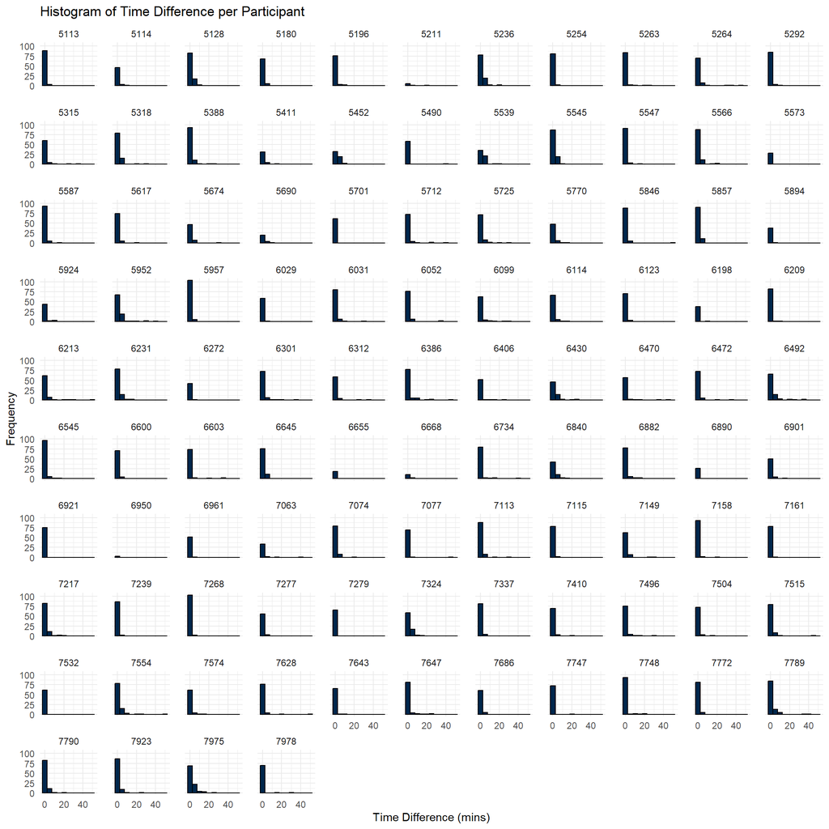

```r
# Filter the dataset to drop rows where any of the conditions are met
EMA.DIGIT3_filtered <- EMA.DIGIT3 %>%
  filter(!(TTCFlag_High == 1 | TTCFlag_Low == 1))

## round to nearest 0.5 minutes for visualization
EMA.DIGIT3_filtered <- EMA.DIGIT3_filtered %>%
  mutate(
    minutes = time_diff / 60,
    minutes_rounded = floor(minutes * 2 + 0.5) / 2 )

ggplot(EMA.DIGIT3_filtered, aes(x = minutes_rounded)) +
  geom_histogram(binwidth = 5, fill = "#00274C", color = "black") +
  facet_wrap(~ participantidentifier) +
  labs(title = "Histogram of Time Difference per Participant",
       x = "Time Difference (mins)",
       y = "Frequency") +
  theme_minimal() +
  theme(
       panel.spacing = unit(1, "lines")   #increase spacing between plots
  )
```

### 3.3.2 SD histograms

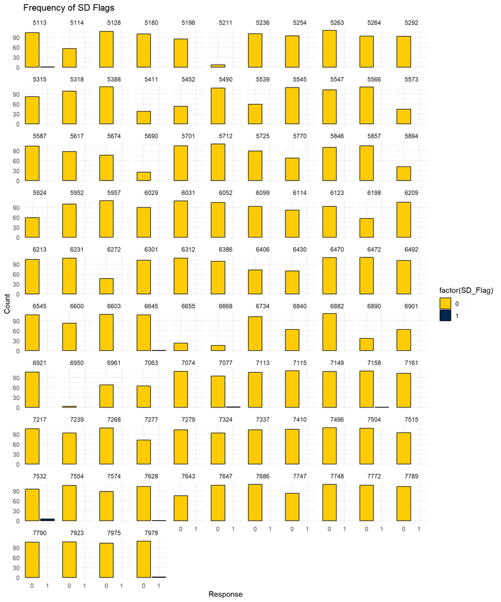

```r
# SD FLAGS
df_counts <- EMA.DIGIT3 %>%
  count(participantidentifier, SD_Flag)

ggplot(df_counts, aes(x = factor(SD_Flag), y = n, fill = factor(SD_Flag))) +
  geom_col(color = "black") +
  facet_wrap(~ participantidentifier) +
  labs(title = "Frequency of SD Flags",
       x = "Response",
       y = "Count") +
  scale_fill_manual(values = c("0" = unname(plot_colors["um_maize"]),  "1" = unname(plot_colors["um_blue"]))) +
  theme_minimal()
```

# 4 Compliance

## 4.1 Missing Data Summary

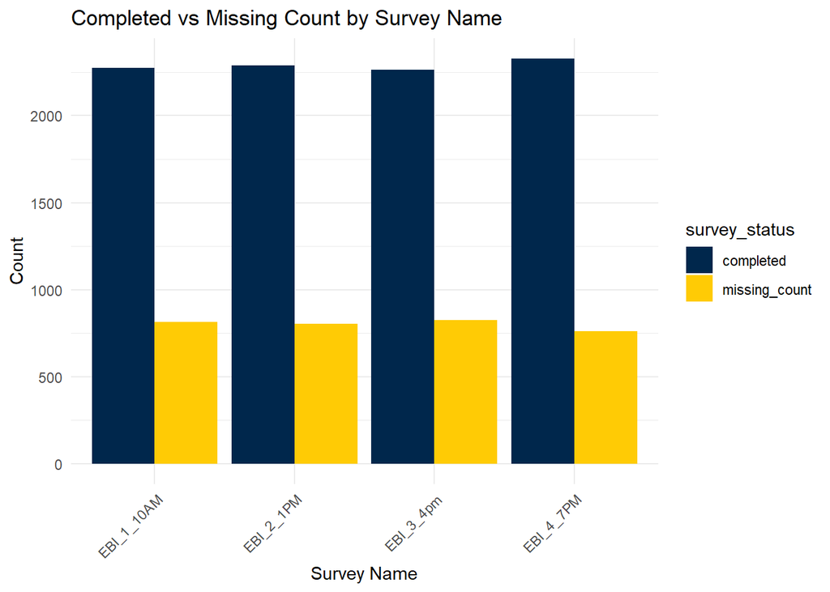

```r
# Remove duplicates and keep the first occurrence based on participantidentifier, dayinstudy, and surveyname
EMA.DIGIT4 <- EMA.DIGIT3 %>%
  arrange(participantidentifier, dayinstudy, surveyname) %>%  # Arrange by the relevant columns
  distinct(participantidentifier, dayinstudy, surveyname, .keep_all = TRUE)  # Keep first occurrence

# Define all possible survey names
survey_names <-  EMA.DIGIT4$surveyname %>% unique()

# Create a complete dataset with all combinations of participant, day, and surveyname. Our current dataset only has completed surveys, so it's important we know what's really missing
expected_surveys <- EMA.DIGIT4 %>%
  distinct(participantidentifier, dayinstudy) %>%
  tidyr::expand(participantidentifier, dayinstudy, surveyname = survey_names)

# Count actual completed surveys per participant per day per surveyname
actual_surveys <- EMA.DIGIT4 %>%
  group_by(participantidentifier, dayinstudy, surveyname) %>%
  summarise(completed = n(), .groups = "drop")

# Merge expected and actual surveys
missing_surveys <- expected_surveys %>%
  left_join(actual_surveys, by = c("participantidentifier", "dayinstudy", "surveyname")) %>%
  mutate(completed = ifelse(is.na(completed), 0, completed),  # Replace NA with 0
         missing_count = 1 - completed)  # 1 if missing, 0 if completed


## Plot missingness count by survey_name

# Aggregate data to sum completed and missing_count for each surveyname
survey_summary <- missing_surveys %>%
  group_by(surveyname) %>%
  summarise(completed = sum(completed, na.rm = TRUE),
            missing_count = sum(missing_count, na.rm = TRUE)) %>%
  ungroup()

# Reshape the data to long format
long_data <- survey_summary %>%
  pivot_longer(cols = c(completed, missing_count),
               names_to = "survey_status",
               values_to = "count")  # Convert to long format

# Create the grouped bar chart
ggplot(long_data, aes(x = surveyname, y = count, fill = survey_status)) +
  geom_bar(stat = "identity", position = "dodge") +  # Side-by-side bars
  labs(x = "Survey Name", y = "Count", title = "Completed vs Missing Count by Survey Name") +  # Labels & title
  theme_minimal() +  # Clean theme
  theme(axis.text.x = element_text(angle = 45, hjust = 1)) +  # Rotate x-axis labels
  scale_fill_manual(values = c("completed" = unname(plot_colors["um_blue"]), "missing_count" = unname(plot_colors["um_maize"])))
```

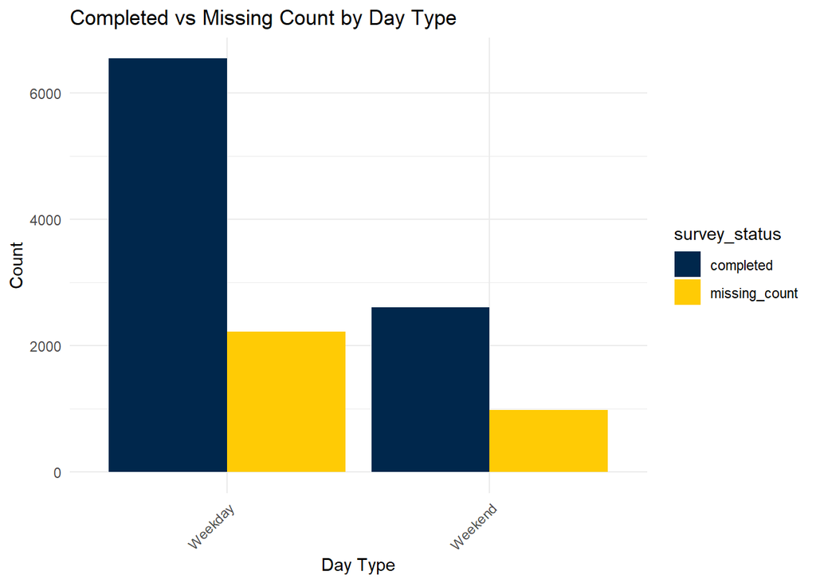

```r
## Plot missingness count by weekday vs. weekend

## Get other variables we want to add to missingsurvey

Vars <- EMA.DIGIT4 %>%
  select(participantidentifier, dayinstudy, surveyname,
         day_type, deviceplatform, participant_group)


missing_surveys2 <- merge(missing_surveys, Vars, by = c("participantidentifier", "dayinstudy", "surveyname"), all.x = TRUE)

missing_surveys2 <- missing_surveys2 %>%
  group_by(participantidentifier) %>%
  fill(day_type, deviceplatform, participant_group, .direction = "downup") %>%  # Specify .direction only once
  ungroup()

# Aggregate data to sum completed and missing_count for each surveyname
survey_summary <- missing_surveys2 %>%
  group_by(day_type) %>%
  summarise(completed = sum(completed, na.rm = TRUE),
            missing_count = sum(missing_count, na.rm = TRUE)) %>%
  ungroup()

# Reshape the data to long format
long_data <- survey_summary %>%
  pivot_longer(cols = c(completed, missing_count),
               names_to = "survey_status",
               values_to = "count")  # Convert to long format

# Create the grouped bar chart
ggplot(long_data, aes(x = day_type, y = count, fill = survey_status)) +
  geom_bar(stat = "identity", position = "dodge") +  # Side-by-side bars
  labs(x = "Day Type", y = "Count", title = "Completed vs Missing Count by Day Type") +  # Labels & title
  theme_minimal() +  # Clean theme
  theme(axis.text.x = element_text(angle = 45, hjust = 1)) +  # Rotate x-axis labels
  scale_fill_manual(values = c("completed" = unname(plot_colors["um_blue"]), "missing_count" = unname(plot_colors["um_maize"])))
```

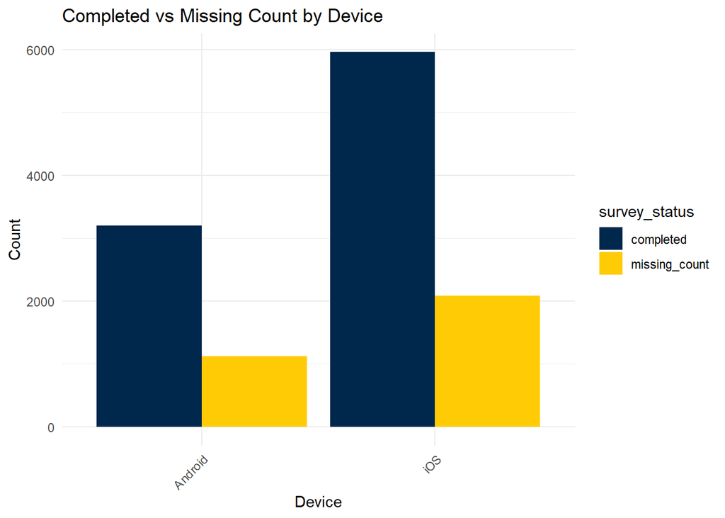

```r
## Now plot completion v. deviceplatform

# Aggregate data to sum completed and missing_count for each surveyname
survey_summary <- missing_surveys2 %>%
  group_by(deviceplatform) %>%
  summarise(completed = sum(completed, na.rm = TRUE),
            missing_count = sum(missing_count, na.rm = TRUE)) %>%
  ungroup()

# Reshape the data to long format
long_data <- survey_summary %>%
  pivot_longer(cols = c(completed, missing_count),
               names_to = "survey_status",
               values_to = "count")  # Convert to long format

# Create the grouped bar chart
ggplot(long_data, aes(x = deviceplatform, y = count, fill = survey_status)) +
  geom_bar(stat = "identity", position = "dodge") +  # Side-by-side bars
  labs(x = "Device", y = "Count", title = "Completed vs Missing Count by Device") +  # Labels & title
  theme_minimal() +  # Clean theme
  theme(axis.text.x = element_text(angle = 45, hjust = 1)) +  # Rotate x-axis labels
  scale_fill_manual(values = c("completed" = unname(plot_colors["um_blue"]), "missing_count" = unname(plot_colors["um_maize"])))
```

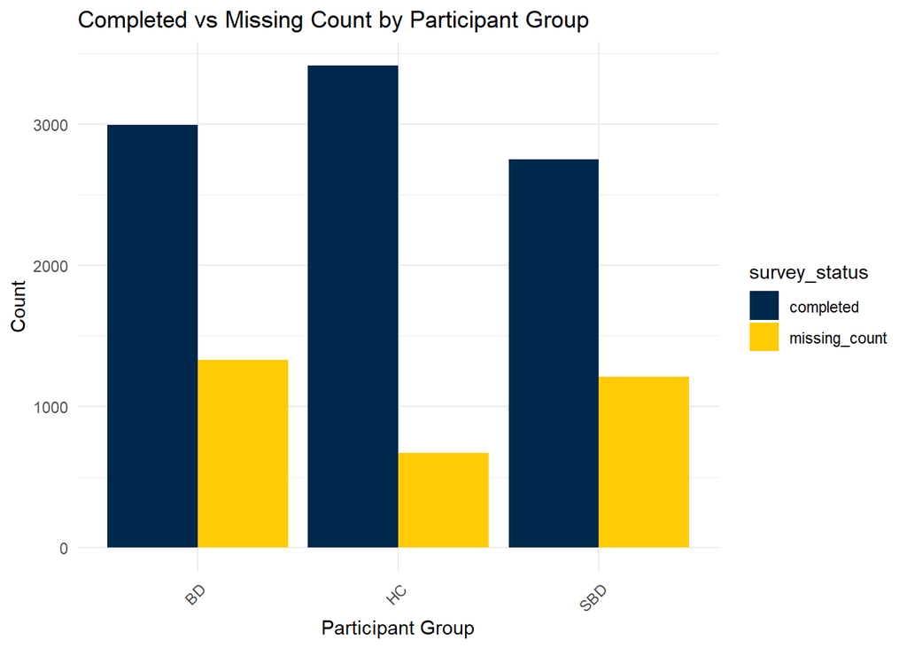

```r
## Now do it for participant groups (diagnosis, cohort, etc.)

# Aggregate data to sum completed and missing_count for each participant group
survey_summary <- missing_surveys2 %>%
  group_by(participant_group) %>%
  summarise(completed = sum(completed, na.rm = TRUE),
            missing_count = sum(missing_count, na.rm = TRUE)) %>%
  ungroup()

# Reshape the data to long format
long_data <- survey_summary %>%
  pivot_longer(cols = c(completed, missing_count),
               names_to = "survey_status",
               values_to = "count")  # Convert to long format

# Create the grouped bar chart
ggplot(long_data, aes(x = participant_group, y = count, fill = survey_status)) +
  geom_bar(stat = "identity", position = "dodge") +  # Side-by-side bars
  labs(x = "Participant Group", y = "Count", title = "Completed vs Missing Count by Participant Group") +  # Labels & title
  theme_minimal() +  # Clean theme
  theme(axis.text.x = element_text(angle = 45, hjust = 1)) +  # Rotate x-axis labels
  scale_fill_manual(values = c("completed" = unname(plot_colors["um_blue"]), "missing_count" = unname(plot_colors["um_maize"])))
```

## 4.2 Figures for percent compliance

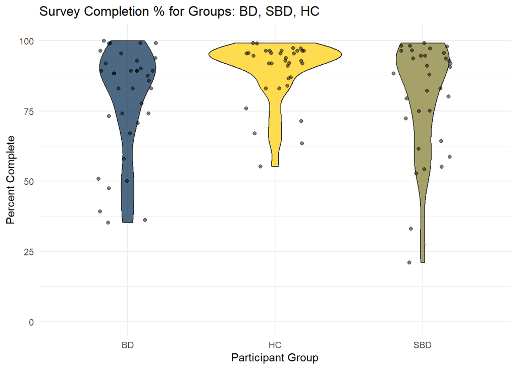

```r
# Compliance summary
df_compliance <- EMA.DIGIT4 %>%
  group_by(participantidentifier) %>%
  summarise(
    total_completed = sum(!is.na(surveyname)),
    total_expected = max(dayinstudy, na.rm = TRUE) * surveys_per_day,
    percent_compliance = (total_completed / total_expected) * 100,
    participant_group = first(participant_group)
  )

df_compliance$participant_group <- as.factor(df_compliance$participant_group)

# Get all unique groups & set chunk size
group_levels <- unique(df_compliance$participant_group)
groups_per_plot <- 4

# Split groups into chunks of 4
group_slices <- split(group_levels, ceiling(seq_along(group_levels) / groups_per_plot))

# Loop and create compliance by participant violin plots, with max 4 groups at a time
for (i in seq_along(group_slices)) {
  current_groups <- group_slices[[i]]

  # Subset data
  df_sub <- df_compliance %>%
    filter(participant_group %in% current_groups)

  # Dynamic color palette for each group
  current_colors <- get_color_gradient(
    as.character(current_groups),
    from_col = plot_colors["um_blue"],
    to_col   = plot_colors["um_maize"]
  )

  # Make and print the plot
  p <- ggplot(df_sub, aes(x = participant_group, y = percent_compliance, fill = participant_group)) +
    geom_violin(trim = TRUE, alpha = 0.7) +
    geom_jitter(width = 0.2, alpha = 0.5) +
    scale_fill_manual(values = current_colors) +
    labs(
      title = paste("Survey Completion % for Groups:", paste(current_groups, collapse = ", ")),
      x = "Participant Group",
      y = "Percent Complete"
    ) +
    theme_minimal() +
    theme(legend.position = "none") +
    ylim(0,101)

  print(p)
}
```

## 4.3 Compliance table

```r
table1(~ percent_compliance  | participant_group, data=df_compliance)
```

|  | BD (N=36) | HC (N=34) | SBD (N=33) | Overall (N=103) |
| --- | --- | --- | --- | --- |
| percent_compliance |  |  |  |  |
| Mean (SD) | 79.3 (19.2) | 89.4 (10.8) | 80.2 (20.0) | 82.9 (17.6) |
| Median [Min, Max] | 87.9 [35.2, 100] | 93.3 [55.2, 99.1] | 88.4 [21.1, 99.1] | 89.3 [21.1, 100] |

# 5 Item Distribution

## 5.1 Histograms of EMA items

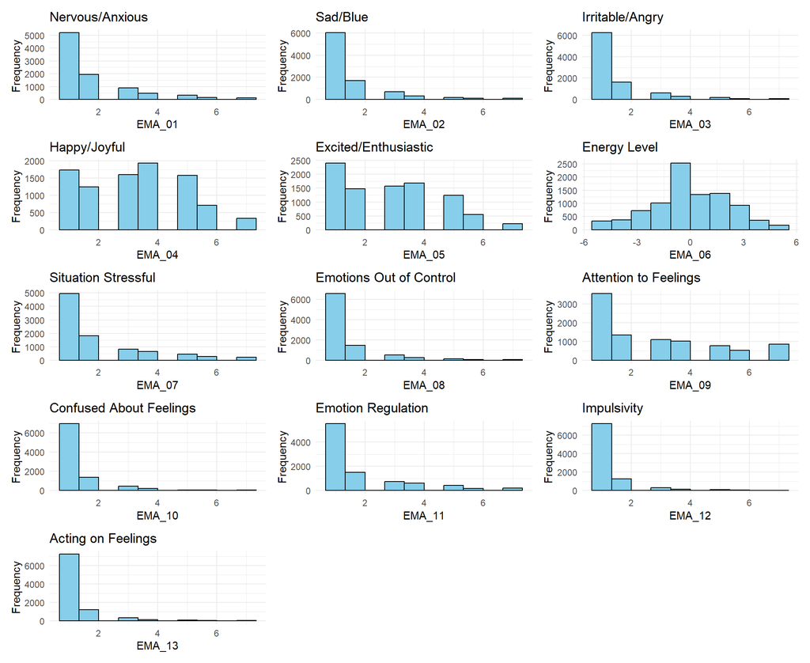

```r
# Function for plotting histogram
plot_list <- lapply(ema_vars, function(var){ # use previously defined ema_vars

  ggplot(EMA.DIGIT4, aes(x = .data[[var]])) +
    geom_histogram(bins = 10, fill = "skyblue", color = "black") +
    labs(
      title = ema_item_labels[[var]],
      x = var,
      y = "Frequency"
    ) +
    theme_minimal()
})

# Plot on a grid
combined_histograms <- wrap_plots(plot_list, ncol = 3)

combined_histograms
```

## 5.2 Item by within day time effect

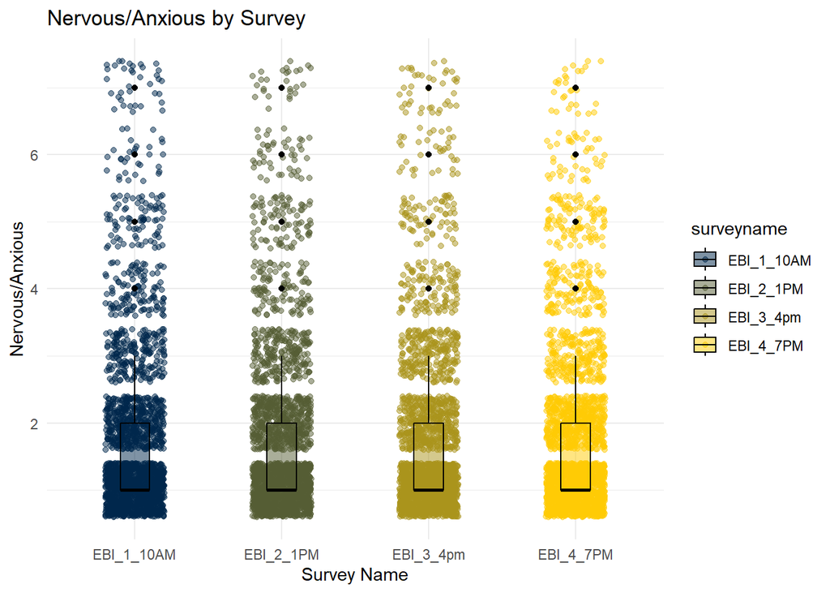

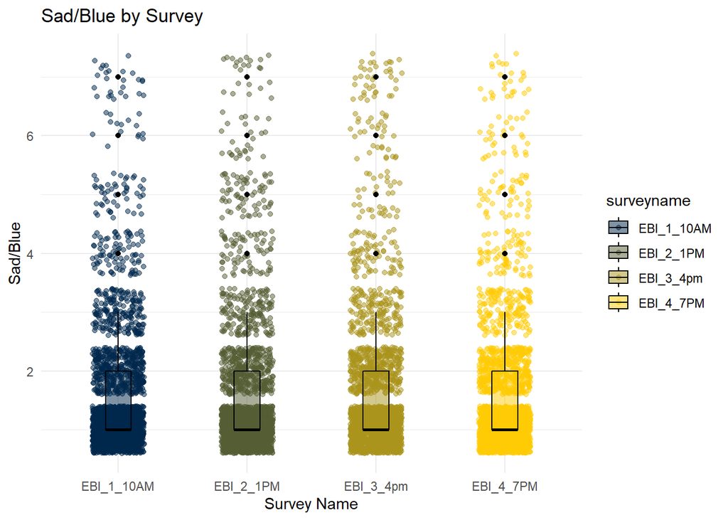

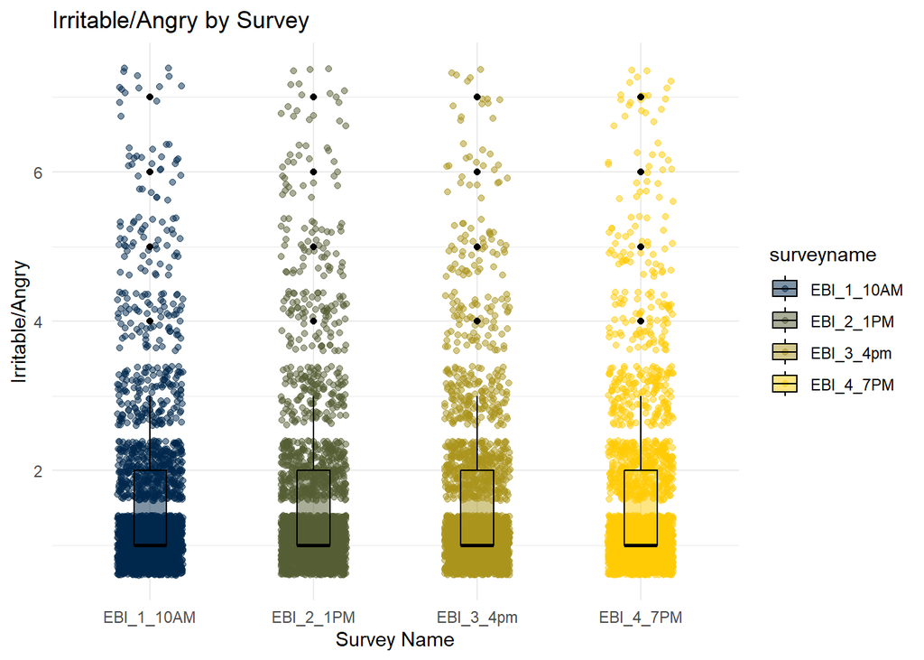

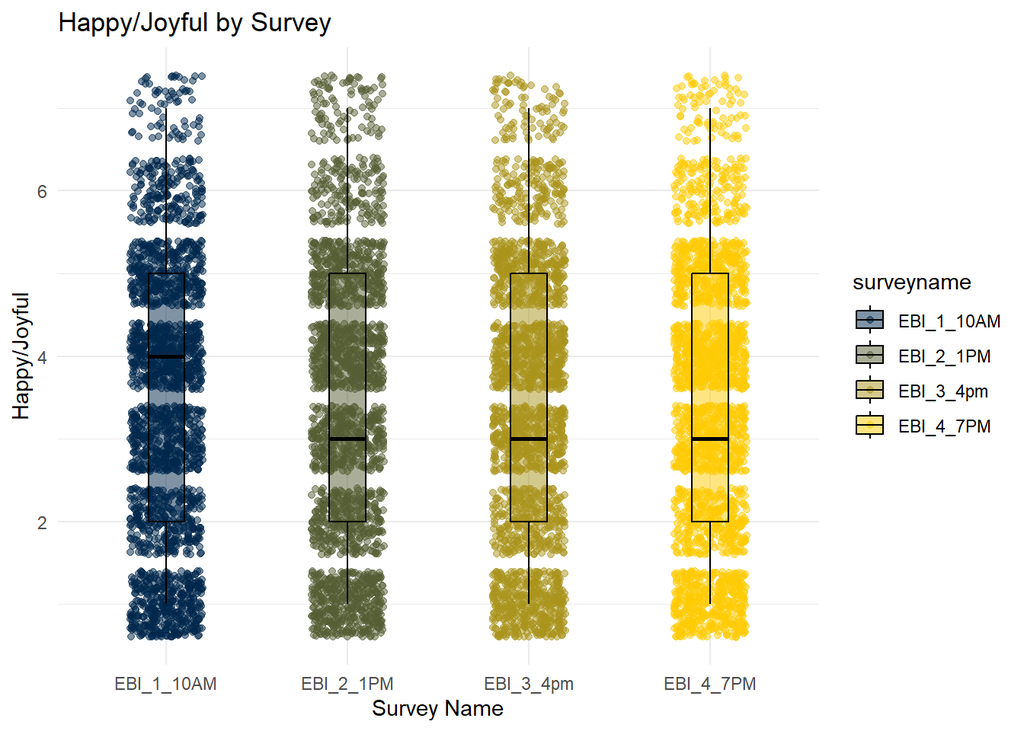

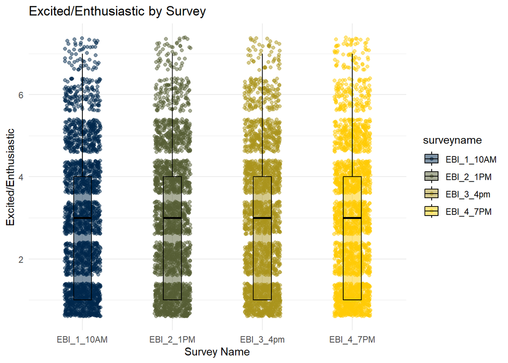

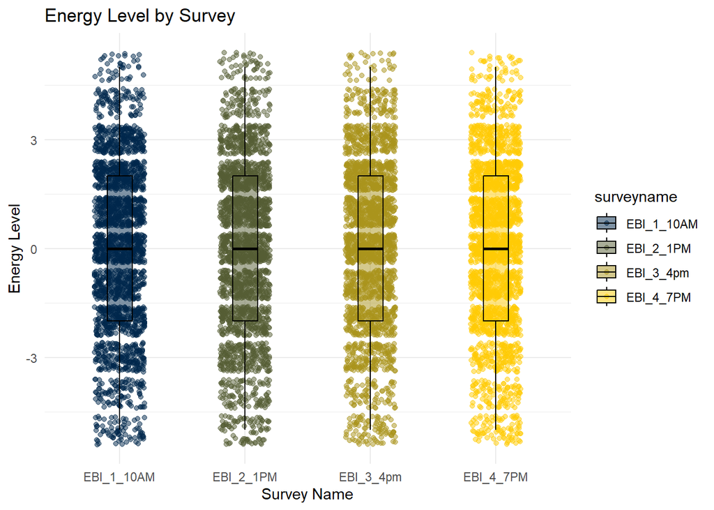

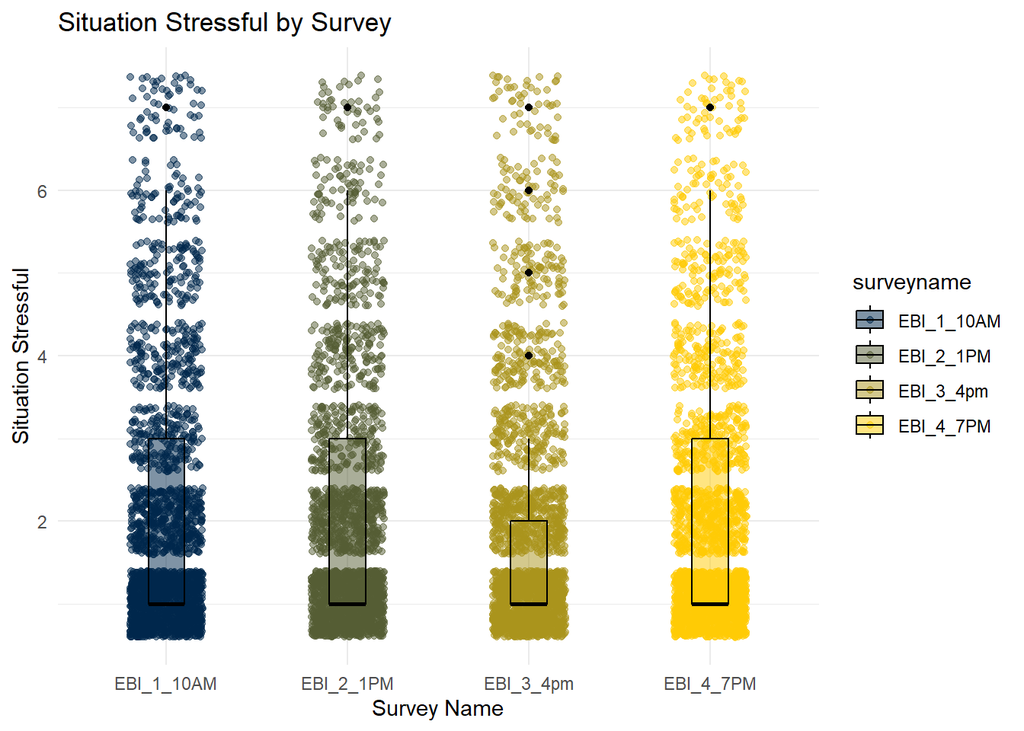

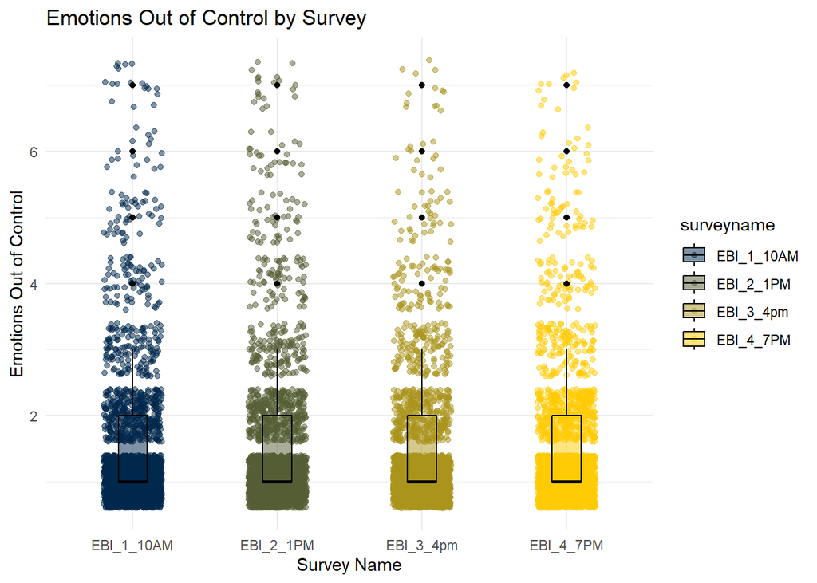

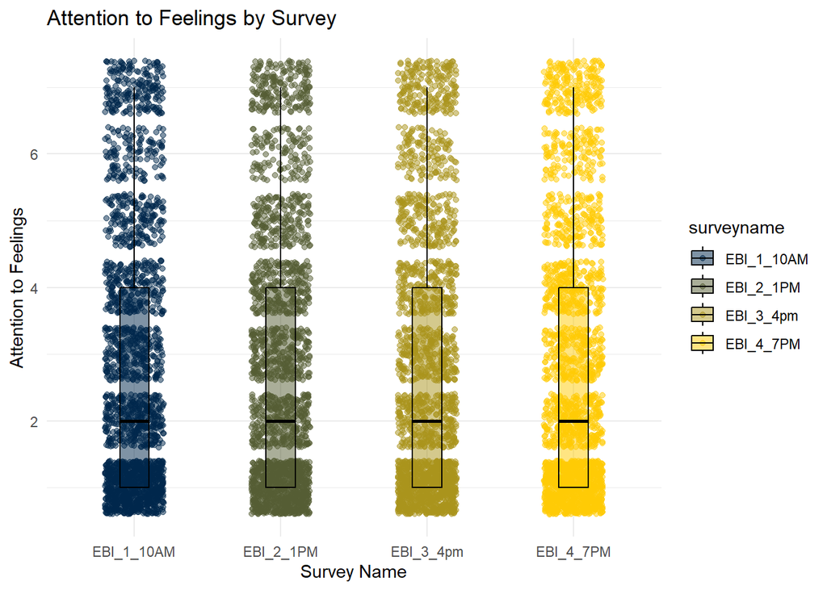

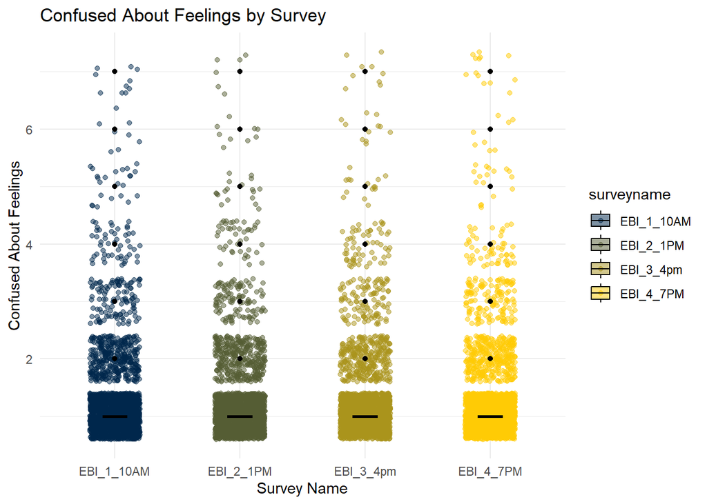

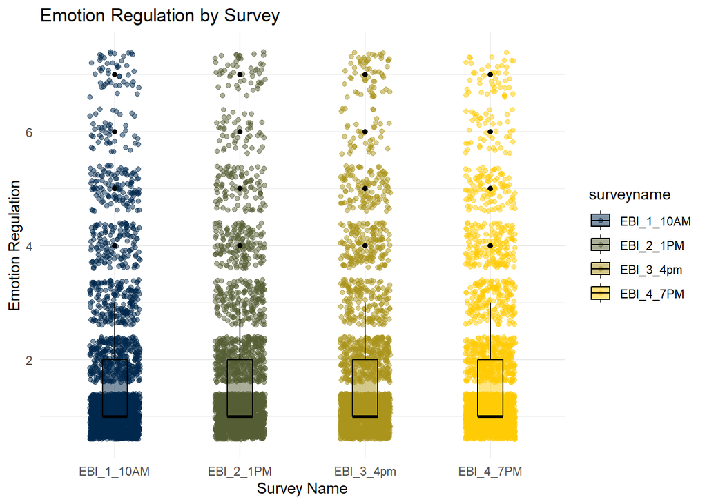

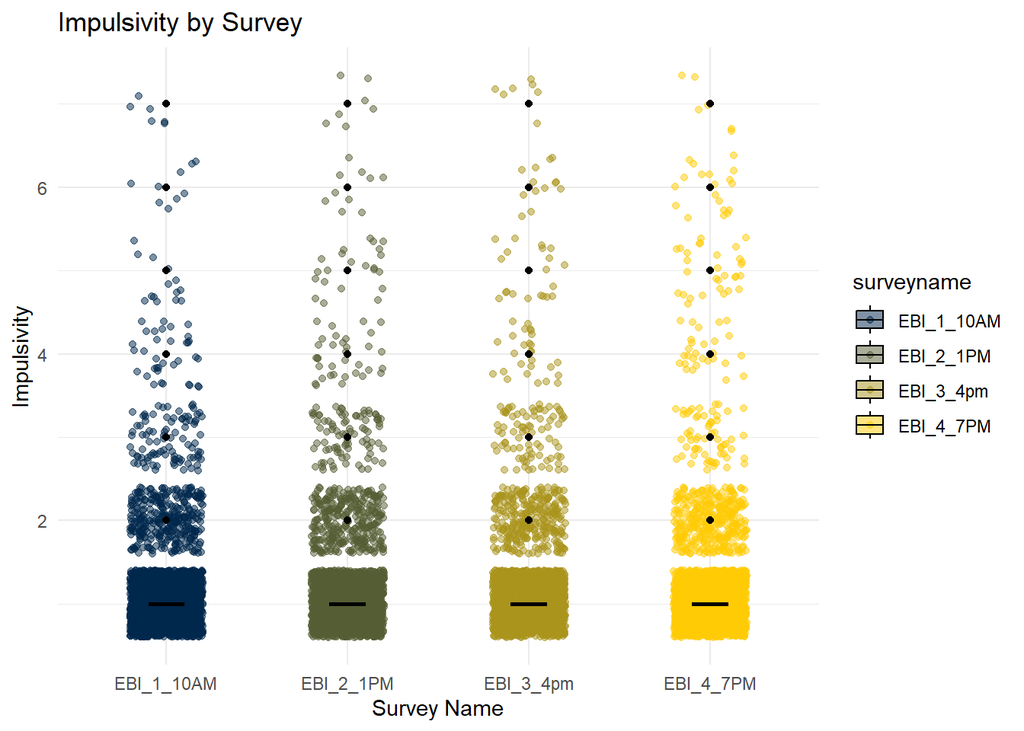

[1 more figures not shown]

```r
survey_names <- unique(EMA.DIGIT4$surveyname)
num_surveys <- length(survey_names)
survey_colors <- get_color_gradient(survey_names)
names(survey_colors) <- survey_names


ema_plots <- lapply(ema_vars, function(item) {
  plot_ema_by_survey(EMA.DIGIT4, item, survey_colors, ema_item_labels)
})

for (i in seq_along(ema_vars)) {
  print(ema_plots[[i]])
}
```

# 6 Correlation

## 6.1 Correlation matrix

```r
# Define the corrmatrix
corrmatrix <- EMA.DIGIT4 %>%
 select(participantidentifier, starts_with(ema_item_prefix))

# For ema item labels, retrieve the ones corresponding to the actual columns in the correlation matrices
current_ema_items <- names(corrmatrix)[names(corrmatrix) != "participantidentifier"]
current_item_labels <- ema_item_labels[current_ema_items]

StatsBetween <- statsBy(corrmatrix, group = "participantidentifier", cors = FALSE, method="spearman", na.rm = TRUE)

Betweencorr <- as.matrix (StatsBetween$rbg) ## this is between person r value
betweenp <- as.matrix(StatsBetween$pbg) ## this is between person p value
betweenm <- as.matrix(StatsBetween$mean) ## This is person centered mean
Withincorr <- as.matrix (StatsBetween$rwg) ## this is within person r value
withinp <- as.matrix(StatsBetween$pwg) ## this is within person p value
withinsd <- as.matrix(StatsBetween$sd) ## this is the within-person SD
```

## 6.2 Plot correlogram

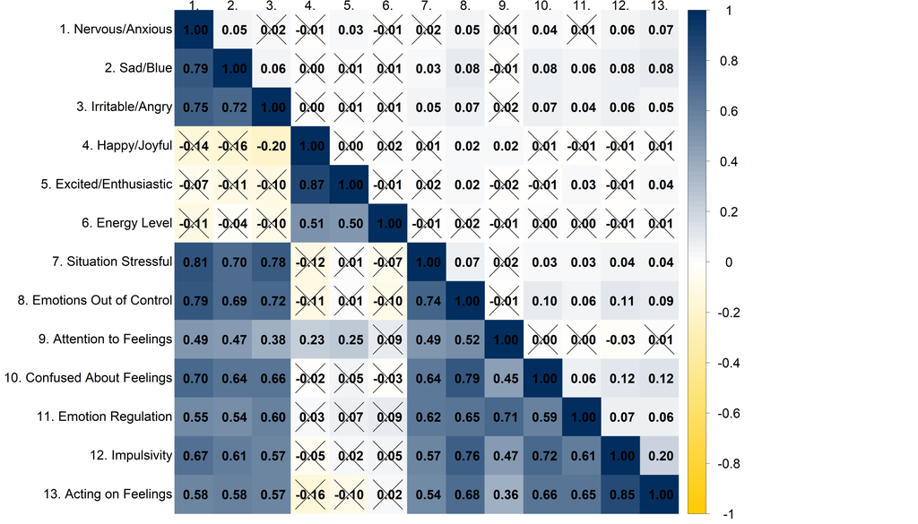

```r
# define color palette
my_col <- colorRampPalette(c(plot_colors["um_maize"], "white", plot_colors["um_dark_blue"]))(100)


# Set readable labels for corrplot using your labels param
rownames(Betweencorr) <- paste0(seq_along(current_item_labels), ". ", current_item_labels)
colnames(Betweencorr) <- rep("", length(current_item_labels))
rownames(Withincorr) <- rep("", length(current_item_labels))
colnames(Withincorr) <- paste0(seq_along(current_item_labels), ".")

# Plot within correlations on the upper diagonal
corrplot(Withincorr,
         type = "upper",
         method = "color",
         col = my_col,
         p.mat = withinp,
         sig.level = 0.05,
         insig = "pch",
         addCoef.col = "black",
         tl.col = "black",
         na.label = "--",
         pch.cex = 15,
         tl.srt = 0,
         tl.cex = 3,
         number.cex = 3,
         cl.cex = 3,
         number.digits = 2)

# Plot between person correlations on the lower diagonal
corrplot(Betweencorr,
         type = "lower",
         method = "color",
         col = my_col,
         p.mat = betweenp,
         sig.level = 0.05,
         insig = "pch",
         addCoef.col = "black",
         tl.col = "black",
         pch.cex = 15,
         tl.cex = 3,
         number.cex = 3,
         cl.pos = "n",
         add = TRUE) # plots between and within together on the same plot!
```

# 7 Output

The correlation tables are saved as individual CSVs in the output_dir directory.

```r
# Create csv files of correlation tables
write.csv(Betweencorr, file = file.path(output_dir, "Betweencorr.csv"))
write.csv(Withincorr, file = file.path(output_dir, "Withincorr.csv"))
write.csv(betweenm, file = file.path(output_dir, "betweenm.csv"))
write.csv(betweenp, file = file.path(output_dir, "betweenp.csv"))
write.csv(withinp, file = file.path(output_dir, "withinp.csv"))
write.csv(withinsd, file = file.path(output_dir, "withinsd.csv"))

# For HTML report (from R console or script)
#rmarkdown::render("EMA-CleanR.Rmd", output_dir = output_dir)
```

For instructions and more information on this program, please visit our GitHub page at: https://github.com/DepressionCenter/EMA-CleanR

# 8 License

## 8.1 Copyright Notice

Copyright © 2025 The Regents of the University of Michigan

## 8.2 Software and Library License Notice

This program is free software: you can redistribute it and/or modify it under the terms of the GNU General Public License as published by the Free Software Foundation, either version 3 of the License, or (at your option) any later version.

This program is distributed in the hope that it will be useful, but WITHOUT ANY WARRANTY; without even the implied warranty of MERCHANTABILITY or FITNESS FOR A PARTICULAR PURPOSE. See the GNU General Public License for more details.

You should have received a copy of the GNU General Public License along with this program. If not, see https://www.gnu.org/licenses/gpl-3.0-standalone.html.

## 8.3 Documentation License Notice

Permission is granted to copy, distribute and/or modify this document under the terms of the GNU Free Documentation License, Version 1.3 or any later version published by the Free Software Foundation; with no Invariant Sections, no Front-Cover Texts, and no Back-Cover Texts. You should have received a copy of the license included in the section entitled “GNU Free Documentation License”. If not, see https://www.gnu.org/licenses/fdl-1.3-standalone.html

## 8.4 Citation

If you find this repository, code or paper useful for your research, please cite it.

#### 8.4.0.1 Citation Example:

> Sperry, Sarah; Murphy, Victoria (2025). EMA-CleanR. University of Michigan. Software. https://github.com/DepressionCenter/EMA-CleanR  
>  *DOI: 10.5281/zenodo.17982076*

Copyright © 2025 The Regents of the University of Michigan